# R Notebook - Descibing Data II

# One Quantitative Variable

## Histograms

Graphs for 1 Quantitative var

```r
#fetching the dataset
data(airquality)
#Compactly display the internal structure of the object
str(airquality)
```

```
'data.frame':   153 obs. of  6 variables:
 $ Ozone  : int  41 36 12 18 NA 28 23 19 8 NA ...
 $ Solar.R: int  190 118 149 313 NA NA 299 99 19 194 ...
 $ Wind   : num  7.4 8 12.6 11.5 14.3 14.9 8.6 13.8 20.1 8.6 ...
 $ Temp   : int  67 72 74 62 56 66 65 59 61 69 ...
 $ Month  : int  5 5 5 5 5 5 5 5 5 5 ...
 $ Day    : int  1 2 3 4 5 6 7 8 9 10 ...
```

Choosing a “feature” a.k.a Quantitative var = Temperature

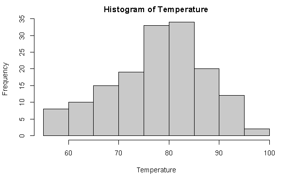

```r
Temperature <- airquality$Temp
hist(Temperature)
```

If we want to have the probability distribution instead of the actual frequency, we can set the parameter ‘freq=F’

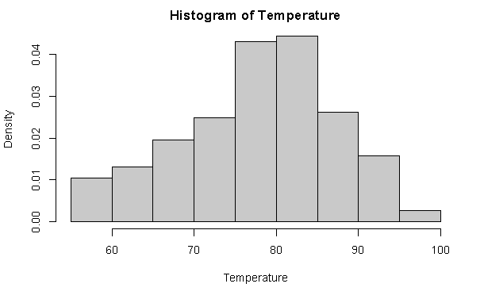

```r
hist(Temperature, freq = F)
```

The hist() function returns a list of 6 objects :

- $breaks: Bins of the graph
- $counts: Frequency (for each bin?- to check)
- $density: probability
- $mids (mid points of the cells)
- xname: x arguments of the cells
- equidist: Bollean indicating that the breaks are equally spaced

We can use the return values of the hist for further processing

```r
#use the return from hist to complete the histogram
h = hist(Temperature, ylim = c(0,40))
#see the contents of h (previous hist)
str(h)
```

```
List of 6
 $ breaks  : int [1:10] 55 60 65 70 75 80 85 90 95 100
 $ counts  : int [1:9] 8 10 15 19 33 34 20 12 2
 $ density : num [1:9] 0.0105 0.0131 0.0196 0.0248 0.0431 ...
 $ mids    : num [1:9] 57.5 62.5 67.5 72.5 77.5 82.5 87.5 92.5 97.5
 $ xname   : chr "Temperature"
 $ equidist: logi TRUE
 - attr(*, "class")= chr "histogram"
```

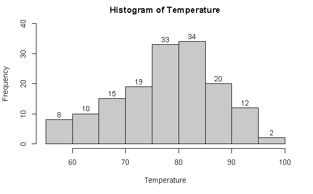

```r
# use these to complete the graph
text(h$mids, h$counts, labels = h$counts, adj=c(0.5, -0.5))
```

#### Truehist() a Hist() alternative

Scales the counts to give an estimate of the probability

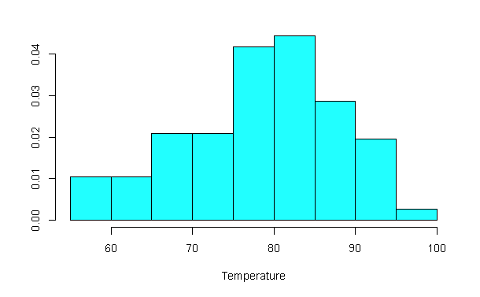

```r
th = truehist(Temperature)
```

```r
th
```

## Shape

Measures of central tendency

- Mean
- Median - Middle of a distribution that is ordered from lowest to highest value in the X-axis
- Mode - Value with the highest frequency

Note:R does not have a standard in-built function to calculate mode. So we create a user function to calculate mode of a data set in R. This function takes the vector as input and gives the mode value as output.

Simple example

```r
ex = c(5,7,8,9,9,11,13)
# function to calculate the mode
getmode <- function(v) {
   uniqv <- unique(v)
   uniqv[which.max(tabulate(match(v, uniqv)))]
}
ex_ct=c(mean(ex), median(ex), getmode(ex))
str(ex_ct)
```

[output not shown]